# sklearn实现决策树，支持向量机，集成学习，非均衡采样，模型评估

#### 版权所有 翻版不究 如有雷同 不胜荣幸 （手动狗头）

```python
import numpy as np
import pandas as pd
from IPython.display import Image
import pydotplus
from sklearn.tree import export_graphviz
from sklearn.tree import DecisionTreeClassifier
from sklearn.model_selection import train_test_split
from sklearn.datasets import load_breast_cancer
import pydot
import os
```

## 1. 基础决策树

```python
#3：1拆分数据集
#乳腺癌数据集
cancer = load_breast_cancer()
#参数random_state是指随机生成器，0表示函数输出是固定不变的
X_train,X_test,y_train,y_test = train_test_split(cancer['data'],cancer['target'],random_state=42)
tree = DecisionTreeClassifier(random_state=0)
tree.fit(X_train,y_train)
print('Train score:{:.3f}'.format(tree.score(X_train,y_train)))
print('Test score:{:.3f}'.format(tree.score(X_test,y_test)))
#生成可视化图
export_graphviz(tree,out_file="tree.dot",class_names=['严重','轻微'],feature_names=cancer.feature_names,impurity=False,filled=True)
#展示可视化图
(graph,) = pydot.graph_from_dot_file('tree.dot')
graph.write_png('C://Users//l//Desktop//datamining_mypre//decisiontree//tree.png')
```

```
Train score:1.000
Test score:0.930
```

### plus 进行预剪枝 结果变化 减轻过拟合

```python
cancer = load_breast_cancer()
#参数random_state是指随机生成器，0表示函数输出是固定不变的
X_train,X_test,y_train,y_test = train_test_split(cancer['data'],cancer['target'],random_state=42)
#设置深度为4，即产生4个问题就停止生长 max_depth=4
tree = DecisionTreeClassifier(max_depth=4,random_state=0)
tree.fit(X_train,y_train)
print('Train score:{:.3f}'.format(tree.score(X_train,y_train)))
print('Test score:{:.3f}'.format(tree.score(X_test,y_test)))
#生成可视化图
#生成可视化图
export_graphviz(tree,out_file="tree.dot",class_names=['严重','轻微'],feature_names=cancer.feature_names,impurity=False,filled=True)
#展示可视化图
(graph,) = pydot.graph_from_dot_file('tree.dot')
graph.write_png('C://Users//l//Desktop//datamining_mypre//decisiontree//tree2.png')
```

```
Train score:0.995
Test score:0.951
```

训练集error增大，但是测试集error减小

## 2. 随机森林 http://www.pianshen.com/article/5989300134/

```python
import numpy as np
import pandas as pd
import matplotlib.pyplot as plt
import seaborn as sns
data_train = pd.read_csv(r'C:\Users\l\Desktop\datamining_mypre\train.csv') # Data From Kaggle
data_test = pd.read_csv(r'C:\Users\l\Desktop\datamining_mypre\test.csv') ### test data里没有存活数据
# data_train.info()  #显示数据信息
```

```python
data_train.head()
```

|  | PassengerId | Survived | Pclass | Name | Sex | Age | SibSp | Parch | Ticket | Fare | Cabin | Embarked |
| --- | --- | --- | --- | --- | --- | --- | --- | --- | --- | --- | --- | --- |
| 0 | 1 | 0 | 3 | Braund, Mr. Owen Harris | male | 22.0 | 1 | 0 | A/5 21171 | 7.2500 | NaN | S |
| 1 | 2 | 1 | 1 | Cumings, Mrs. John Bradley (Florence Briggs Th... | female | 38.0 | 1 | 0 | PC 17599 | 71.2833 | C85 | C |
| 2 | 3 | 1 | 3 | Heikkinen, Miss. Laina | female | 26.0 | 0 | 0 | STON/O2. 3101282 | 7.9250 | NaN | S |
| 3 | 4 | 1 | 1 | Futrelle, Mrs. Jacques Heath (Lily May Peel) | female | 35.0 | 1 | 0 | 113803 | 53.1000 | C123 | S |
| 4 | 5 | 0 | 3 | Allen, Mr. William Henry | male | 35.0 | 0 | 0 | 373450 | 8.0500 | NaN | S |

### 数据相关性分析（可视化)

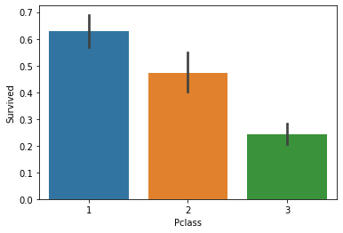

```python
sns.barplot(x='Pclass',y='Survived',data=data_train)
```

舱位等级越高生存率就越高

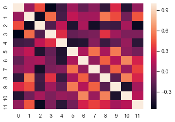

```python
### 来个热力图（相关系数的可视化）(题外话)
sns.set()
np.random.seed(0)
uniform_data = np.random.rand(10, 12)
cor = pd.DataFrame(uniform_data).corr()
ax = sns.heatmap(cor)
plt.show()
```

### 数据预处理

补全年龄的缺失值,通过求性别与舱位这两个类来补全缺少的年龄值 (本文的方法是针对性别和所在舱位来逆推出年龄） 但是这需要对性别（男，女）进行数值化处理，我们给定男：1 女：0

```python
combine = [data_train,data_test]
for dataset in combine:
    dataset['Sex'] = dataset['Sex'].map({'female':0, 'male':1}).astype(int)  #将性别变为数字的格式
dataset.iloc[0:5]
```

|  | PassengerId | Pclass | Name | Sex | Age | SibSp | Parch | Ticket | Fare | Cabin | Embarked |
| --- | --- | --- | --- | --- | --- | --- | --- | --- | --- | --- | --- |
| 0 | 892 | 3 | Kelly, Mr. James | 1 | 34.5 | 0 | 0 | 330911 | 7.8292 | NaN | Q |
| 1 | 893 | 3 | Wilkes, Mrs. James (Ellen Needs) | 0 | 47.0 | 1 | 0 | 363272 | 7.0000 | NaN | S |
| 2 | 894 | 2 | Myles, Mr. Thomas Francis | 1 | 62.0 | 0 | 0 | 240276 | 9.6875 | NaN | Q |
| 3 | 895 | 3 | Wirz, Mr. Albert | 1 | 27.0 | 0 | 0 | 315154 | 8.6625 | NaN | S |
| 4 | 896 | 3 | Hirvonen, Mrs. Alexander (Helga E Lindqvist) | 0 | 22.0 | 1 | 1 | 3101298 | 12.2875 | NaN | S |

```python
guess_ages = np.zeros((2,3))  #创造矩阵
for dataset in combine:
    for i in range(0,2):
        for j in range(0,3):
            age_guess = dataset[(dataset['Sex']==i)&(dataset['Pclass']==j+1)]['Age'].dropna()    #将非空的年龄数值进行存储
            guess = age_guess.median()   #算出该类别下的平均年龄
            guess_ages[i,j] = int(guess/0.5+0.5)*0.5  #这个是为了保证平均年龄更加准确
    for i in range(0,2):
        for j in range(0,3):
            dataset.loc[(dataset.Age.isnull())&(dataset.Sex == i)&(dataset.Pclass == j+1),'Age'] = guess_ages[i,j]   #将空白的年龄值按类别补上
    dataset['Age'] = dataset['Age'].astype(int)

data_train.iloc[0:5]
```

|  | PassengerId | Survived | Pclass | Name | Sex | Age | SibSp | Parch | Ticket | Fare | Cabin | Embarked |
| --- | --- | --- | --- | --- | --- | --- | --- | --- | --- | --- | --- | --- |
| 0 | 1 | 0 | 3 | Braund, Mr. Owen Harris | 1 | 22 | 1 | 0 | A/5 21171 | 7.2500 | NaN | S |
| 1 | 2 | 1 | 1 | Cumings, Mrs. John Bradley (Florence Briggs Th... | 0 | 38 | 1 | 0 | PC 17599 | 71.2833 | C85 | C |
| 2 | 3 | 1 | 3 | Heikkinen, Miss. Laina | 0 | 26 | 0 | 0 | STON/O2. 3101282 | 7.9250 | NaN | S |
| 3 | 4 | 1 | 1 | Futrelle, Mrs. Jacques Heath (Lily May Peel) | 0 | 35 | 1 | 0 | 113803 | 53.1000 | C123 | S |
| 4 | 5 | 0 | 3 | Allen, Mr. William Henry | 1 | 35 | 0 | 0 | 373450 | 8.0500 | NaN | S |

年龄补充完成之后我们希望把年龄分组化，也即是将年龄进行分组处理，并赋予一个新的值 e.g. 1-20岁定义为1，这样的好处在于方便我们进行算法的类别划分，减少过拟合情况出现

```python
data_train['AgeBand'] = pd.cut(data_train['Age'], 5)
data_train[['AgeBand', 'Survived']].groupby(['AgeBand'], as_index=False).mean().sort_values(by='AgeBand', ascending=True) #先分组再重新定义
for dataset in combine:
    dataset.loc[ dataset['Age'] <= 16, 'Age'] = 0
    dataset.loc[(dataset['Age'] > 16) & (dataset['Age'] <= 32), 'Age'] = 1
    dataset.loc[(dataset['Age'] > 32) & (dataset['Age'] <= 48), 'Age'] = 2
    dataset.loc[(dataset['Age'] > 48) & (dataset['Age'] <= 64), 'Age'] = 3
    dataset.loc[ dataset['Age'] > 64, 'Age']
data_train.head()
```

|  | PassengerId | Survived | Pclass | Name | Sex | Age | SibSp | Parch | Ticket | Fare | Cabin | Embarked | AgeBand |
| --- | --- | --- | --- | --- | --- | --- | --- | --- | --- | --- | --- | --- | --- |
| 0 | 1 | 0 | 3 | Braund, Mr. Owen Harris | 1 | 1 | 1 | 0 | A/5 21171 | 7.2500 | NaN | S | (16.0, 32.0] |
| 1 | 2 | 1 | 1 | Cumings, Mrs. John Bradley (Florence Briggs Th... | 0 | 2 | 1 | 0 | PC 17599 | 71.2833 | C85 | C | (32.0, 48.0] |
| 2 | 3 | 1 | 3 | Heikkinen, Miss. Laina | 0 | 1 | 0 | 0 | STON/O2. 3101282 | 7.9250 | NaN | S | (16.0, 32.0] |
| 3 | 4 | 1 | 1 | Futrelle, Mrs. Jacques Heath (Lily May Peel) | 0 | 2 | 1 | 0 | 113803 | 53.1000 | C123 | S | (32.0, 48.0] |
| 4 | 5 | 0 | 3 | Allen, Mr. William Henry | 1 | 2 | 0 | 0 | 373450 | 8.0500 | NaN | S | (32.0, 48.0] |

```python
import pandas as pd
import numpy as np
import random as rnd

# visualization
import seaborn as sns
import matplotlib.pyplot as plt


# machine learning
from sklearn.linear_model import LogisticRegression
from sklearn.svm import SVC, LinearSVC
from sklearn.ensemble import RandomForestClassifier
from sklearn.neighbors import KNeighborsClassifier
from sklearn.naive_bayes import GaussianNB
from sklearn.linear_model import Perceptron
from sklearn.linear_model import SGDClassifier
from sklearn.tree import DecisionTreeClassifier
#分测试集与训练集
X_train = data_train.drop(['Name','Ticket','Cabin','Embarked','AgeBand','Survived','PassengerId','Fare'], axis=1).copy()
Y_train = data_train["Survived"]
X_test  = data_test.drop(['Name','Ticket','Cabin','Embarked','PassengerId','Fare'], axis=1).copy()
####NA，PersonID(infinity)
```

```python
### 手动再切分测试集训练集
X_train_input = X_train.iloc[0:700]
Y_train_input = Y_train.iloc[0:700]
X_test_input = X_train.iloc[701:891]
Y_test_true = Y_train.iloc[701:891]
```

```python
#进行随机森林算法
random_forest = RandomForestClassifier(n_estimators=100)### 100颗树
random_forest.fit(X_train_input, Y_train_input)
Y_prediction = random_forest.predict(X_test_input)
print('Train score:{:.3f}'.format(random_forest.score(X_train_input, Y_train_input)))
print('Test score:{:.3f}'.format(random_forest.score(X_test_input, Y_test_true)))
```

```
Train score:0.843
Test score:0.847
```

# 随机森林可视化 结果已预储存 for idx, estimator in enumerate(random_forest.estimators_): # 导出dot文件 export_graphviz(estimator, out_file='tree{}.dot'.format(idx), feature_names=X_test_input.columns, class_names=['失踪','存活'], rounded=True, proportion=False, precision=2, filled=True) # 转换为png文件 os.system('dot -Tpng tree{}.dot -o tree{}.png'.format(idx, idx))

```python
#和决策树的PK
tree_titanic = DecisionTreeClassifier(max_depth=4,random_state=0)
tree_titanic.fit(X_train_input,Y_train_input)
print('Train score:{:.3f}'.format(tree_titanic.score(X_train_input, Y_train_input)))
print('Test score:{:.3f}'.format(tree_titanic.score(X_test_input, Y_test_true)))
```

```
Train score:0.820
Test score:0.826
```

## 3.模型评估

```python
from sklearn import metrics
print(metrics.confusion_matrix(Y_test_true,Y_prediction)) # 混淆矩阵
print('准确率：',metrics.accuracy_score(Y_test_true,Y_prediction))
print('类别精度：',metrics.precision_score(Y_test_true,Y_prediction,average = None)) #不求平均
print('宏平均精度：',metrics.precision_score(Y_test_true,Y_prediction,average = 'macro'))
print('微平均召回率:',metrics.recall_score(Y_test_true,Y_prediction,average = 'micro'))
print('加权平均F1得分:',metrics.f1_score(Y_test_true,Y_prediction,average = 'weighted'))
```

```
[[106  14]
 [ 15  55]]
准确率： 0.8473684210526315
类别精度： [0.87603306 0.79710145]
宏平均精度： 0.836567253563301
微平均召回率: 0.8473684210526315
加权平均F1得分: 0.847136049622848
```

```python
fpr, tpr, thresholds = metrics.roc_curve(Y_test_true, Y_prediction, pos_label = 1)
metrics.auc(fpr, tpr) ### ROC and AUC
```

```
0.8345238095238093
```

## 4.AdaBoost

```python
from sklearn.ensemble import AdaBoostClassifier
from sklearn.model_selection import cross_val_score
AdaBoost_clf = AdaBoostClassifier(n_estimators=10)    # 指定10个弱分类器
AdaBoost_clf.fit(X_train_input,Y_train_input)
Y_prediction = AdaBoost_clf.predict(X_test_input)
print('Train score:{:.3f}'.format(AdaBoost_clf.score(X_train_input, Y_train_input)))
print('Test score:{:.3f}'.format(AdaBoost_clf.score(X_test_input, Y_test_true)))
```

```
Train score:0.807
Test score:0.816
```

```python
scores = cross_val_score(AdaBoost_clf,X_train_input,Y_train_input,cv = 5) # 模型 数据集 目标变量 #交叉验证
print(scores)#均方误
```

```
[0.80851064 0.80714286 0.85       0.78571429 0.76258993]
```

## 5.支持向量机

#### 基础剖析 https://blog.csdn.net/u010665216/article/details/78382984

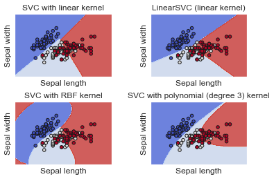

```python
import numpy as np
import matplotlib.pyplot as plt
from sklearn import svm, datasets


def make_meshgrid(x, y, h=.02):
    """Create a mesh of points to plot in

    Parameters
    ----------
    x: data to base x-axis meshgrid on
    y: data to base y-axis meshgrid on
    h: stepsize for meshgrid, optional

    Returns
    -------
    xx, yy : ndarray
    """
    x_min, x_max = x.min() - 1, x.max() + 1
    y_min, y_max = y.min() - 1, y.max() + 1
    xx, yy = np.meshgrid(np.arange(x_min, x_max, h),
                         np.arange(y_min, y_max, h))
    return xx, yy


def plot_contours(ax, clf, xx, yy, **params):
    """Plot the decision boundaries for a classifier.

    Parameters
    ----------
    ax: matplotlib axes object
    clf: a classifier
    xx: meshgrid ndarray
    yy: meshgrid ndarray
    params: dictionary of params to pass to contourf, optional
    """
    Z = clf.predict(np.c_[xx.ravel(), yy.ravel()])
    Z = Z.reshape(xx.shape)
    out = ax.contourf(xx, yy, Z, **params)
    return out


# import some data to play with
iris = datasets.load_iris()
# Take the first two features. We could avoid this by using a two-dim dataset
X = iris.data[:, :2]
y = iris.target

# we create an instance of SVM and fit out data. We do not scale our
# data since we want to plot the support vectors
C = 1.0  # SVM regularization parameter
models = (svm.SVC(kernel='linear', C=C),
          svm.LinearSVC(C=C, max_iter=10000),
          svm.SVC(kernel='rbf', gamma=0.7, C=C),
          svm.SVC(kernel='poly', degree=3, gamma='auto', C=C))
models = (clf.fit(X, y) for clf in models)

# title for the plots
titles = ('SVC with linear kernel',
          'LinearSVC (linear kernel)',
          'SVC with RBF kernel',
          'SVC with polynomial (degree 3) kernel')

# Set-up 2x2 grid for plotting.
fig, sub = plt.subplots(2, 2)
plt.subplots_adjust(wspace=0.4, hspace=0.4)

X0, X1 = X[:, 0], X[:, 1]
xx, yy = make_meshgrid(X0, X1)

for clf, title, ax in zip(models, titles, sub.flatten()):
    plot_contours(ax, clf, xx, yy,
                  cmap=plt.cm.coolwarm, alpha=0.8)
    ax.scatter(X0, X1, c=y, cmap=plt.cm.coolwarm, s=20, edgecolors='k')
    ax.set_xlim(xx.min(), xx.max())
    ax.set_ylim(yy.min(), yy.max())
    ax.set_xlabel('Sepal length')
    ax.set_ylabel('Sepal width')
    ax.set_xticks(())
    ax.set_yticks(())
    ax.set_title(title)

plt.show()
```

#### SVC with linear kernel V.S. LinearSVC (linear kernel）

#### https://stackoverflow.com/questions/45384185/what-is-the-difference-between-linearsvc-and-svckernel-linear

## 过采样和欠采样

过采样：重复正比例数据，实际上没有为模型引入更多数据，过分强调正比例数据，会放大正比例噪音对模型的影响。（将样本较少的一类sample补齐） 欠采样：丢弃大量数据，和过采样一样会存在过拟合的问题。（将样本较多的一类sample压缩） 由于随机过采样采取简单复制样本的策略来增加少数类样本，这样容易产生模型过拟合的问题，即使得模型学习到的信息过于特别(Specific)而不够泛化(General) 非均衡采样：SMOTE算法

```python
# 使用sklearn的make_classification生成不平衡数据样本
from sklearn.datasets import make_classification
from collections import Counter
# 生成一组0和1比例为9比1的样本，X为特征，y为对应的标签
X, y = make_classification(n_classes=2, class_sep=2,
                           weights=[0.9, 0.1], n_informative=3,
                           n_redundant=1, flip_y=0,
                           n_features=20, n_clusters_per_class=1,
                           n_samples=1000, random_state=10)
# 查看所生成的样本类别分布，0和1样本比例9比1，属于类别不平衡数据
print(Counter(y))
```

```
Counter({0: 900, 1: 100})
```

```python
# 使用imlbearn库中上采样方法中的SMOTE接口
from imblearn.over_sampling import SMOTE
# 定义SMOTE模型，random_state相当于随机数种子的作用
smo = SMOTE(random_state=42)
X_smo, y_smo = smo.fit_sample(X, y)
print(Counter(y_smo))
```

```
Counter({0: 900, 1: 900})
```

从上述代码中可以看出，SMOTE模型默认生成一比一的数据，如果想生成其他比例的数据，可以修改radio参数。 这不仅可以处理二分类问题，同样适用于多分类问题

```python
# 可通过radio参数指定对应类别要生成的数据的数量
smo = SMOTE(ratio={1: 300 },random_state=42)
# 生成0和1比例为3比1的数据样本
X_smo, y_smo = smo.fit_sample(X, y)
print(Counter(y_smo))
```

```
Counter({0: 900, 1: 300})
```